# Laboratório 1, parte 2.

Tendo como público alvo a população eleitoral como um todo, resolvi responder algumas perguntas referentes a dados de participações dos parlamentares no twitter com umas análises.

```r
atividade = read_projectdata()
```

Questão 1: Qual a casa com o maior engajamento_total(medio)? (Ou seja, qual a casa que tem maior engajamento por parlamentar?) A câmara ganha nesse quesito. Os dados estão sendo muito influenciados por valores extremos.

Talvez há algum sentido na minha hipótese de que o senado, por ser a parte supostamente mais sabida do congresso, posta coisas mais engajadas. A resposta da próxima pergunta indica isso.

Qual a casa com a maior mediana do engajamento_total? O senado tem ampla vantagem sobre a câmara nessa estatística. Mesmo divido por 1000000 o boxplot referente aos engaj_total ficaram muito deformados devido a característica dos dados. Muitos outliers detectados.

```r
  atividade[is.na(atividade)] = 0

  atividade_ <- atividade %>% group_by(casa)

  atividade_ %>%
    summarize(media = mean(engaj_total))
```

```
## # A tibble: 2 x 2
##   casa    media
##   <chr>   <dbl>
## 1 câmara 71804.
## 2 senado 66858.
```

```r
  atividade_ %>%
    summarize(mediana = median(engaj_total))
```

```
## # A tibble: 2 x 2
##   casa   mediana
##   <chr>    <dbl>
## 1 câmara      43
## 2 senado    7092
```

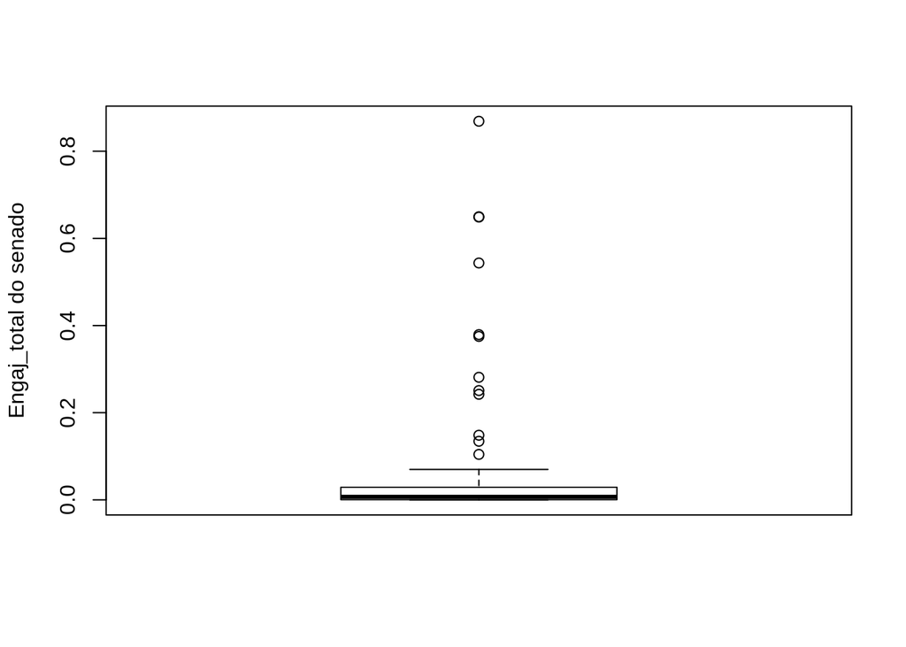

```r
  atividade_camara <- atividade_ %>% filter(casa == "câmara")

  atividade_senado <- atividade_ %>% filter(casa == "senado")

  boxplot(atividade_senado$engaj_total/1000000, ylab="Engaj_total do senado")
```

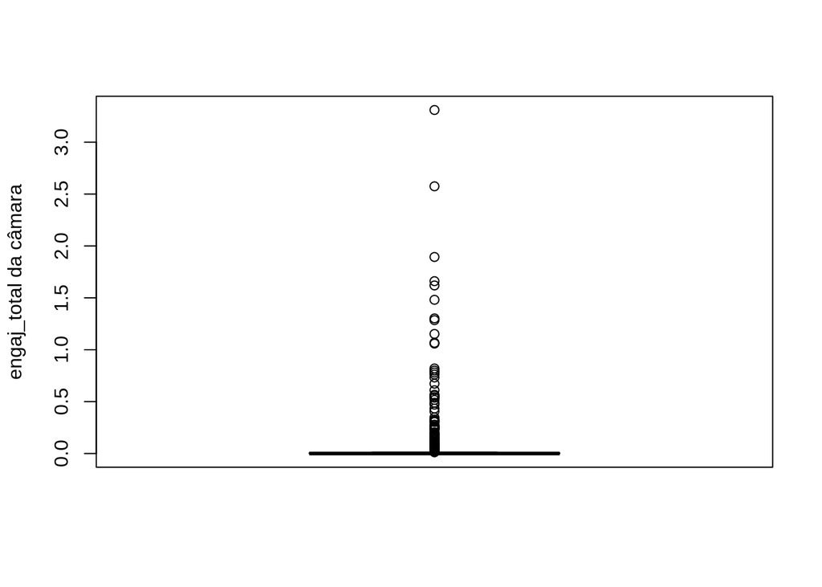

```r
  boxplot(atividade_camara$engaj_total/1000000, ylab="engaj_total da câmara")
```

Questão 2: Quantos e quais parlamentares não tem twitter?

Sem esses que não twitter, qual o engajamento total médio por casa?(A diferença entre as duas casas aumenta bastante uma vez que apenas dois senadores não usam a rede social.)

10% dos parlamentares da câmara não tem twitter enquanto que apenas 2% dos senadores não fazem uso da rede social.

Apesar disso, conforme respondido acima, os dados estão sendo muito influenciados por valores extremos.

```r
  atividade %>%
    filter(twitter == 0) %>%
    select(nome_eleitoral)
```

```
## # A tibble: 59 x 1
##    nome_eleitoral
##    <chr>
##  1 AJ ALBUQUERQUE
##  2 ALCIDES RODRIGUES
##  3 ALEX SANTANA
##  4 ALINE SLEUTJES
##  5 ANDRÉ DE PAULA
##  6 ANDRÉ FERREIRA
##  7 ÁTILA LINS
##  8 BENES LEOCÁDIO
##  9 CORONEL ARMANDO
## 10 CORONEL CHRISÓSTOMO
## # ... with 49 more rows
```

```r
  atividade %>%
    filter(twitter == 0) %>%
    summarize(n())
```

```
## # A tibble: 1 x 1
##   `n()`
##   <int>
## 1    59
```

```r
  # Engajamento total médio por casa tem os parlamentares que não tem twitter
  atividade_ %>%
    filter(twitter != 0) %>%
    summarize(media = mean(engaj_total))
```

```
## # A tibble: 2 x 2
##   casa    media
##   <chr>   <dbl>
## 1 câmara 80512.
## 2 senado 68550.
```

```r
  # Apenas dois senadores não têm twitter
  atividade %>%
    filter(twitter == 0 & casa == "senado") %>%
    select(nome_eleitoral)
```

```
## # A tibble: 2 x 1
##   nome_eleitoral
##   <chr>
## 1 CHICO RODRIGUES
## 2 JAYME CAMPOS
```

```r
  atividade %>%
    filter(twitter == 0 & casa == "senado") %>%
    summarize(n())
```

```
## # A tibble: 1 x 1
##   `n()`
##   <int>
## 1     2
```